# Question

In a deck of strange cards, there are 345 cards. Each card has an image and a color. The amounts are shown in the table below.

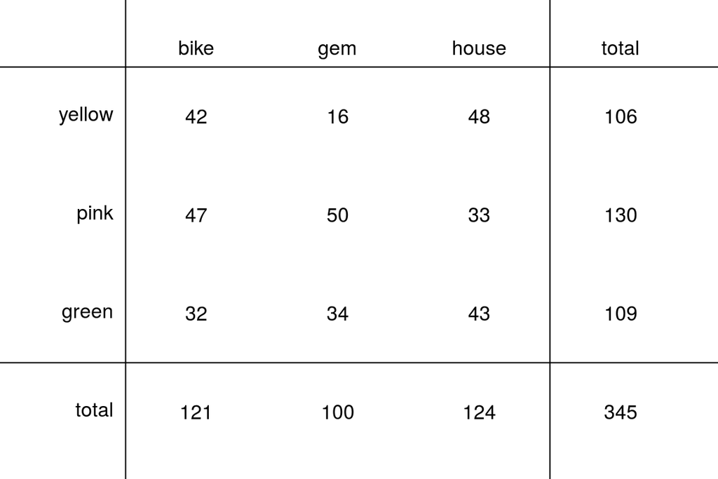

## Answerlist

- What is the probability a random card is pink given it is a gem?
- What is the probability a random card is a bike?
- What is the probability a random card is both a house and yellow?
- What is the probability a random card is pink?
- What is the probability a random card is a gem given it is pink?
- A gem is more likely than a house to be yellow.
- A house is more likely than a gem to be yellow.
- What is the probability a random card is either a house or pink (or both)?

# Solution

## Answerlist

- $P(\text{pink given gem})=\frac{50}{100}=0.5$
- $P(\text{bike})=\frac{121}{345}=0.351$
- $P(\text{house and yellow})=\frac{48}{345}=0.139$
- $P(\text{pink})=\frac{130}{345}=0.377$
- $P(\text{gem given pink})=\frac{50}{130}=0.385$
- $P(\text{yellow given gem}) = 0.16$ and $P(\text{yellow given house}) = 0.387$, so a house is more likely to be yellow than a gem is.
- $P(\text{house or pink})=\frac{124+130-33}{345}=0.641$

# Meta-information

extype: cloze exsolution: 0.5|0.351|0.139|0.377|0.385|01|0.641 exclozetype: num|num|num|num|num|schoice|num exname: Cards probabilities extol: 0.01